# Proyecto_final_MLI

Tomas

2024-03-05

```
  Machine Learning project
  Tomás de Navascués - 2024/02/24
```

PARTE 1: ANÁLISIS DESCRIPTIVO

```r
library(tidyverse)
library(ggplot2)
library(readr)
library(patchwork)
```

Leemos los datos y los limpiamos

```r
test <- read_csv("Breast_Cancer_test_completo (1).csv",
                 col_names = FALSE)
train <- read_delim("Breast_Cancer_train (1).data",
                    delim = "_", escape_double = FALSE, col_names = FALSE,
                    trim_ws = TRUE)

# Combinamos los dataframes para limpiarlos a la vez
data <-rbind(train,test)

# Renombramos las variables
colnames(data) <- c('Sample code number','CT','UCSize','UCShape','MA','SECS','BN','BC',
                    'NN','Mit','Group','Class')

# Limpiamos los datos
data[] <- lapply(data, gsub, pattern='h', replacement='')
data[] <- lapply(data, gsub, pattern='"', replacement='')

#table(data$CT)
data$CT[which(data$CT=='100')] <- 10
data$CT[which(data$CT=='30')] <- 3
data$CT[which(data$CT=='4.0')] <- 4
data$CT[which(data$CT=='80')] <- 8

#table(data$UCSize)
data$UCSize[which(data$UCSize=='30')] <- 3

#table(data$UCShape)
data$UCShape[which(data$UCShape=='-7')] <- 7
data$UCShape[which(data$UCShape=='1.0')] <- 1
data$UCShape[which(data$UCShape=='80')] <- 8

#table(data$MA)
data$MA[which(data$MA=='100')] <- 10
data$MA[which(data$MA=='-1')] <- 1

#table(data$SECS)
data$SECS[which(data$SECS=='100')] <- 10
data$SECS[which(data$SECS=='60')] <- 6

#table(data$BN)

#table(data$BC)
data$MA[which(data$MA=='11')] <- 1

#table(data$NN)
data$NN[which(data$NN=='2.0')] <- 2

#table(data$Mit)

#table(data$Group)
data$Group[which(data$Group=='60')] <- 6

#table(data$Class)
data$Class[which(data$Class=='20')] <- 2
data$Class[which(data$Class=='44')] <- 4
data$Class[which(data$Class=='3')] <- '?'
```

Terminamos de manipular los datos, los guardamos y vemos cómo se distribuyen

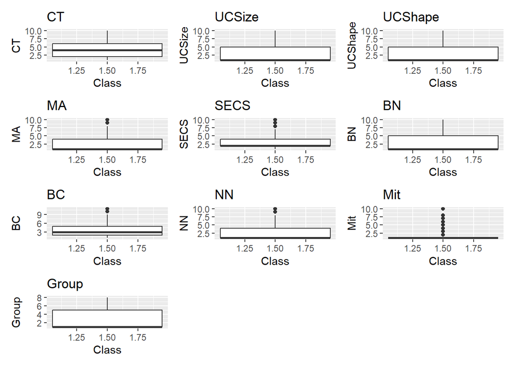

```r
# Convertimos los datos en variables numéricas para hacer boxplots
data$CT <- as.numeric(data$CT)
data$UCSize <- as.numeric(data$UCSize)
data$UCShape <- as.numeric(data$UCShape)
data$MA <- as.numeric(data$MA)
data$SECS <- as.numeric(data$SECS)
data$BN <- as.numeric(data$BN)
data$BC <- as.numeric(data$BC)
data$NN <- as.numeric(data$NN)
data$Mit <- as.numeric(data$Mit)
data$Group <- as.numeric(data$Group)
data$Class <- as.numeric(data$Class)

# Convertimos la variable target en un factor y le asignamos los niveles correspondientes
data$Class <- as.factor(data$Class)
levels(data$Class) <- c("B", "M") # B = Benigno, M = Maligno

# Guardamos el dataset limpiado
save(data, file="data_modificado.RData")

# Hacemos boxplots de las variables para ver cómo se distribuyen

plots_list <- list()
train <- data[1:559,]
train$Class <- as.numeric(train$Class)

for(variable in colnames(data[2:11])){
  plot <- ggplot(train,aes(x=Class,y=!!sym(variable)))+
    geom_boxplot()+
    ggtitle(paste(variable))
  plots_list[[variable]]<-plot
}
all_plots <- wrap_plots(plots_list,ncol = 3)
print(all_plots)
```

Se ve claramente que los datos no son normales, y que, en muchos casos, se concentran en ciertos valores. Sin embargo, hablar aquí de normalidad propiamente no tiene mucho sentido porque son variables numéricas discretas, en una escala de menor a mayor de 1 a 10. Por tanto, hablar de que sigan una distribución normal continua no tiene sentido.

Además, tampoco consideraremos que son factores como tal, puesto que, aunque sean discretas, sí que son cuantitativas, ya que implican una gradación de menos (1) a más (10). En este sentido, aplicar transformaciones como las de boxcox no tiene mucho sentido, ni tampoco centrarlos y escalarlos. Por eso, pasaremos a la realización del modelo sin manipular más los datos.

PARTE 2: CONSTRUCCIÓN DEL MODELO

```r
# Cargamos el dataset limpiado
load("data_modificado.RData")

# Lo separamos en las variables para el train y el test
train <- data[1:559,]
test <- data[560:699,]


### Hacemos las comparaciones bivariantes con el target y eliminamos las variables que
# no son significativas.
vector_con_datos <- NULL

for(columna in 2:11){
  #print(names(train)[columna])
  temporal <- data.frame(train[,c(columna,12)])
  formula <- as.formula(paste0("Class ~", names(train)[columna]))
  mod <- glm(formula, data = temporal, family = binomial(link = "logit"))

  ss <- summary(mod)
  coef <- ss$coefficients

  if(nrow(coef)>2)
  {
    hasta <- nrow(coef)
    for(agregar in 2:hasta)
    {
      vector_con_datos <- c(vector_con_datos, rownames(coef)[agregar], coef[agregar,1], coef[agregar,4])
    }
  } else {
    vector_con_datos <- c(vector_con_datos, names(train)[columna], coef[2,1], coef[2,4])
  }

}

df <- data.frame(matrix(vector_con_datos, ncol = 3, byrow = T))
names(df) <- c("Factor","Estimate","Value")
print(df)
```

```
##     Factor          Estimate                Value
## 1       CT 0.920247048647195 1.44607807243538e-29
## 2   UCSize  1.39312525190502 6.74695354259658e-28
## 3  UCShape  1.34353786151594 1.57549261641012e-29
## 4       MA   1.0003778573616 2.56551832103013e-26
## 5     SECS  1.24945327775911 1.80850767208882e-27
## 6       BN 0.883395877420944 2.24270909091633e-26
## 7       BC  1.28527422814088 4.17135536252732e-27
## 8       NN 0.863591652184628 4.95199310187437e-25
## 9      Mit  1.83047202493719 6.06003750120004e-11
## 10   Group -0.18142304283932 2.09541318623147e-06
```

Vemos que cada variable por separado sale significativa, por lo que de momento no eliminamos ninguna.

Ahora construimos el modelo global, con todas las variables:

```r
mod <- glm("Class ~ .", data = train[,-1], family = binomial(link="logit"))
summary(mod)
```

```
##
## Call:
## glm(formula = "Class ~ .", family = binomial(link = "logit"),
##     data = train[, -1])
##
## Coefficients:
##              Estimate Std. Error z value Pr(>|z|)
## (Intercept) -10.41554    1.57750  -6.603 4.04e-11 ***
## CT            0.63727    0.18840   3.383 0.000718 ***
## UCSize       -0.03662    0.25395  -0.144 0.885327
## UCShape       0.20207    0.27864   0.725 0.468332
## MA            0.45787    0.14441   3.171 0.001521 **
## SECS         -0.02413    0.17237  -0.140 0.888650
## BN            0.35969    0.10437   3.446 0.000568 ***
## BC            0.56528    0.17498   3.231 0.001236 **
## NN            0.34170    0.14095   2.424 0.015341 *
## Mit           0.68151    0.55483   1.228 0.219326
## Group        -0.17195    0.15778  -1.090 0.275808
## ---
## Signif. codes:  0 '***' 0.001 '**' 0.01 '*' 0.05 '.' 0.1 ' ' 1
##
## (Dispersion parameter for binomial family taken to be 1)
##
##     Null deviance: 695.780  on 535  degrees of freedom
## Residual deviance:  77.721  on 525  degrees of freedom
##   (23 observations deleted due to missingness)
## AIC: 99.721
##
## Number of Fisher Scoring iterations: 9
```

Vamos quitando las variables no significativas. Consideramos no significativas aquellas con un p-valor mayor que 0.05

```r
mod <- glm("Class ~ CT + UCShape + MA + SECS + BN + BC + NN + Mit + Group",
           data = train[,-1], family = binomial(link="logit"))

mod <- glm("Class ~ CT + UCShape + MA + BN + BC + NN + Mit + Group",
           data = train[,-1], family = binomial(link="logit"))

mod <- glm("Class ~ CT + MA + BN + BC + NN + Mit + Group",
           data = train[,-1], family = binomial(link="logit"))

mod <- glm("Class ~ CT + MA + BN + BC + NN + Mit",
           data = train[,-1], family = binomial(link="logit"))

mod <- glm("Class ~ CT + MA + BN + BC + NN",
           data = train[,-1], family = binomial(link="logit"))
summary(mod)
```

```
##
## Call:
## glm(formula = "Class ~ CT + MA + BN + BC + NN", family = binomial(link = "logit"),
##     data = train[, -1])
##
## Coefficients:
##              Estimate Std. Error z value Pr(>|z|)
## (Intercept) -10.77456    1.38335  -7.789 6.77e-15 ***
## CT            0.81236    0.16822   4.829 1.37e-06 ***
## MA            0.44496    0.13225   3.364 0.000767 ***
## BN            0.41318    0.09601   4.304 1.68e-05 ***
## BC            0.58222    0.16080   3.621 0.000294 ***
## NN            0.41778    0.11714   3.567 0.000362 ***
## ---
## Signif. codes:  0 '***' 0.001 '**' 0.01 '*' 0.05 '.' 0.1 ' ' 1
##
## (Dispersion parameter for binomial family taken to be 1)
##
##     Null deviance: 697.515  on 537  degrees of freedom
## Residual deviance:  83.065  on 532  degrees of freedom
##   (21 observations deleted due to missingness)
## AIC: 95.065
##
## Number of Fisher Scoring iterations: 8
```

Una vez que tenemos el modelo predecimos en el dataframe del test

```r
prediccion <- predict(mod, type = "response", newdata = test)
datos_predict <- cbind(test, prediccion)
```

Ploteamos las predicciones ordenadas:

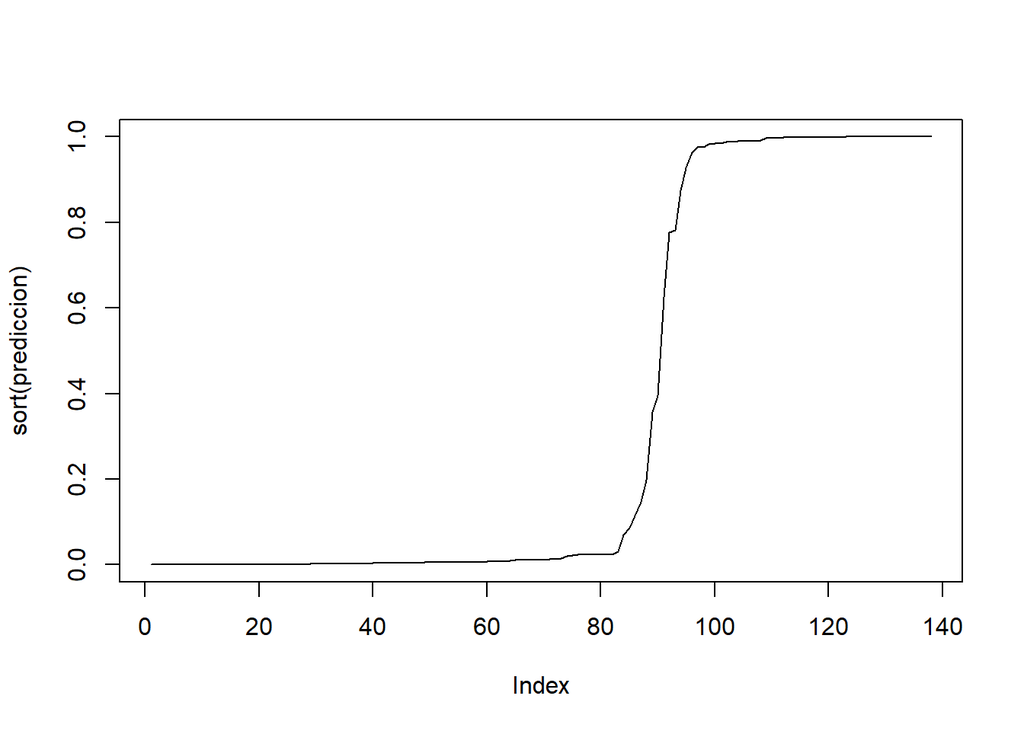

```r
plot(sort(prediccion), type='l')
```

Vemos que hay una transición clara entre los dos niveles del target, esto es, la mayoría de predicciones están en torno al 0 o al 1, lo que significa que se decanta claramente por una de las dos respuestas: benigno o maligno.

Hacemos un corte en 0.5 y consideramos que lo que está a un lado predice benigno y lo que esta al otro predice maligno.

```r
test$predicted <- ifelse(prediccion <= 0.5,0,1)

# Hacemos una tabla para ver los aciertos y los errores:
tt <- table(test$Class,test$predicted)
tt
```

```
##
##      0  1
##   B 89  2
##   M  1 46
```

Calculamos los índices: sensibilidad, especificidad y precisión.

```r
# Se considerarán los tumores benignos como positivos y los malignos como negativos.
sensibilidad = tt[1,1]/(tt[1,1]+tt[1,2]) # los TP (true positive) entre TP+FN (falso negativo)
especificidad = tt[2,2]/(tt[2,2]+tt[2,1]) # los TN (true negative) entre TN + FP
precision = (tt[1,1]+tt[2,2])/(tt[1,1]+tt[1,2]+tt[2,1]+tt[2,2]) # TP+TN entre todos
print(c(sensibilidad,especificidad,precision))
```

```
## [1] 0.9780220 0.9787234 0.9782609
```

Podemos ver que los índices salen muy altos, por lo que nuestro modelo predice en general de forma muy correcta.

Ahora hacemos el cross-validation dividiendo el dataset del train en tres slots. Para cada slot consideraremos que es el validation y que el training dataset son los dos slots restantes, y haremos predict en el validation. De este modo queremos ver si los resultados, o sea, las predicciones, dependen mucho de los datos con los que se hace el train, y lo veremos a través de los índices de cada uno de los tres modelos.

```r
# Fijamos la semilla para que sea reproducible, a la hora de obtener los mismos slots.
set.seed(1)

sam <- sample(1:nrow(train),nrow(train),replace = FALSE)
sam1 <- sam[1:(nrow(train)/3)]
sam2 <- sam[(nrow(train)/3):(2*(nrow(train)/3))]
sam3 <- sam[(2*(nrow(train)/3)):nrow(train)]

# Separamos el train en tres slots
slot1 <- train[sam1,]
slot2 <- train[sam2,]
slot3 <- train[sam3,]

# Definimos los tres training sets
train1 <- rbind(slot2,slot3)
train2 <- rbind(slot1,slot3)
train3 <- rbind(slot1,slot2)
```

Entrenamos el modelo con cada uno de estos trains. Hacemos el stepwise con cada uno.

```r
## TRAIN1
mod1 <- glm("Class ~ .", data = train1[,-1], family = binomial(link="logit"))

mod1 <- glm("Class ~ CT + UCSize + UCShape +SECS + MA + BN + BC + NN + Mit",
            data = train1[,-1], family = binomial(link="logit"))

mod1 <- glm("Class ~ CT + UCSize + UCShape +SECS + MA + BN + BC + NN",
            data = train1[,-1], family = binomial(link="logit"))

mod1 <- glm("Class ~ CT + UCShape +SECS + MA + BN + BC + NN",
            data = train1[,-1], family = binomial(link="logit"))

mod1 <- glm("Class ~ CT + UCShape + MA + BN + BC + NN",
            data = train1[,-1], family = binomial(link="logit"))

mod1 <- glm("Class ~ CT + UCShape + MA + BC + NN",
            data = train1[,-1], family = binomial(link="logit"))

mod1 <- glm("Class ~ CT + UCShape + MA + BC",
            data = train1[,-1], family = binomial(link="logit"))
summary(mod1)
```

```
##
## Call:
## glm(formula = "Class ~ CT + UCShape + MA + BC", family = binomial(link = "logit"),
##     data = train1[, -1])
##
## Coefficients:
##             Estimate Std. Error z value Pr(>|z|)
## (Intercept) -11.7681     1.9101  -6.161 7.23e-10 ***
## CT            0.8704     0.2389   3.644 0.000269 ***
## UCShape       0.6592     0.2061   3.198 0.001384 **
## MA            0.4027     0.1387   2.903 0.003697 **
## BC            1.0713     0.2884   3.715 0.000203 ***
## ---
## Signif. codes:  0 '***' 0.001 '**' 0.01 '*' 0.05 '.' 0.1 ' ' 1
##
## (Dispersion parameter for binomial family taken to be 1)
##
##     Null deviance: 479.727  on 369  degrees of freedom
## Residual deviance:  61.158  on 365  degrees of freedom
##   (4 observations deleted due to missingness)
## AIC: 71.158
##
## Number of Fisher Scoring iterations: 8
```

```r
## TRAIN2
mod2 <- glm("Class ~ .", data = train2[,-1], family = binomial(link="logit"))

mod2 <- glm("Class ~ CT + UCSize + UCShape + MA + BN + BC + NN + Mit + Group",
            data = train2[,-1], family = binomial(link="logit"))

mod2 <- glm("Class ~ CT + MA + BN + BC + NN + Mit + Group",
            data = train2[,-1], family = binomial(link="logit"))

mod2 <- glm("Class ~ CT + MA + BN + BC + NN + Group",
            data = train2[,-1], family = binomial(link="logit"))

mod2 <- glm("Class ~ CT + MA + BN + BC + NN",
            data = train2[,-1], family = binomial(link="logit"))
summary(mod2)
```

```
##
## Call:
## glm(formula = "Class ~ CT + MA + BN + BC + NN", family = binomial(link = "logit"),
##     data = train2[, -1])
##
## Coefficients:
##             Estimate Std. Error z value Pr(>|z|)
## (Intercept) -10.3342     1.5696  -6.584 4.58e-11 ***
## CT            0.7432     0.1900   3.911 9.18e-05 ***
## MA            0.4331     0.1514   2.860 0.004242 **
## BN            0.4950     0.1373   3.605 0.000312 ***
## BC            0.5333     0.1783   2.990 0.002788 **
## NN            0.4075     0.1365   2.986 0.002825 **
## ---
## Signif. codes:  0 '***' 0.001 '**' 0.01 '*' 0.05 '.' 0.1 ' ' 1
##
## (Dispersion parameter for binomial family taken to be 1)
##
##     Null deviance: 469.121  on 357  degrees of freedom
## Residual deviance:  57.745  on 352  degrees of freedom
##   (15 observations deleted due to missingness)
## AIC: 69.745
##
## Number of Fisher Scoring iterations: 8
```

```r
## TRAIN3
mod3 <- glm("Class ~ .", data = train3[,-1], family = binomial(link="logit"))

mod3 <- glm("Class ~ CT + UCSize + UCShape + MA + SECS + BN + BC + NN + Mit",
            data = train3[,-1], family = binomial(link="logit"))

mod3 <- glm("Class ~ CT + UCSize + MA + SECS + BN + BC + NN + Mit",
            data = train3[,-1], family = binomial(link="logit"))

mod3 <- glm("Class ~ CT + UCSize + MA + BN + BC + NN + Mit",
            data = train3[,-1], family = binomial(link="logit"))

mod3 <- glm("Class ~ CT + MA + BN + BC + NN + Mit",
            data = train3[,-1], family = binomial(link="logit"))
summary(mod3)
```

```
##
## Call:
## glm(formula = "Class ~ CT + MA + BN + BC + NN + Mit", family = binomial(link = "logit"),
##     data = train3[, -1])
##
## Coefficients:
##             Estimate Std. Error z value Pr(>|z|)
## (Intercept) -13.9758     2.9279  -4.773 1.81e-06 ***
## CT            0.8506     0.2530   3.362 0.000775 ***
## MA            0.5636     0.2209   2.551 0.010746 *
## BN            0.4864     0.1337   3.638 0.000275 ***
## BC            0.5406     0.2486   2.175 0.029655 *
## NN            0.4818     0.1909   2.524 0.011594 *
## Mit           1.7019     0.6813   2.498 0.012487 *
## ---
## Signif. codes:  0 '***' 0.001 '**' 0.01 '*' 0.05 '.' 0.1 ' ' 1
##
## (Dispersion parameter for binomial family taken to be 1)
##
##     Null deviance: 463.636  on 359  degrees of freedom
## Residual deviance:  42.374  on 353  degrees of freedom
##   (13 observations deleted due to missingness)
## AIC: 56.374
##
## Number of Fisher Scoring iterations: 9
```

Hacemos predict de cada modelo en su respectivo slot y repetimos los pasos seguidos con el modelo general.

```r
prediccion1 <- predict(mod1,type = "response", newdata = slot1)
prediccion2 <- predict(mod2,type = "response", newdata = slot2)
prediccion3 <- predict(mod3,type = "response", newdata = slot3)

slot1$predicted1 <- ifelse(prediccion1 <= 0.5,0,1)
slot2$predicted2 <- ifelse(prediccion2 <= 0.5,0,1)
slot3$predicted3 <- ifelse(prediccion3 <= 0.5,0,1)

tt1 <- table(slot1$Class,slot1$predicted1)
tt2 <- table(slot2$Class,slot2$predicted2)
tt3 <- table(slot3$Class,slot3$predicted3)

sensibilidad1 = tt1[1,1]/(tt1[1,1]+tt1[1,2])
especificidad1 = tt1[2,2]/(tt1[2,2]+tt1[2,1])
precision1 = (tt1[1,1]+tt1[2,2])/(tt1[1,1]+tt1[1,2]+tt1[2,1]+tt1[2,2])

sensibilidad2 = tt2[1,1]/(tt2[1,1]+tt2[1,2])
especificidad2 = tt2[2,2]/(tt2[2,2]+tt2[2,1])
precision2 = (tt2[1,1]+tt2[2,2])/(tt2[1,1]+tt2[1,2]+tt2[2,1]+tt2[2,2])

sensibilidad3 = tt3[1,1]/(tt3[1,1]+tt3[1,2])
especificidad3 = tt3[2,2]/(tt3[2,2]+tt3[2,1])
precision3 = (tt3[1,1]+tt3[2,2])/(tt3[1,1]+tt3[1,2]+tt3[2,1]+tt3[2,2])
df <- data.frame("sensibilidades" = c(sensibilidad1,sensibilidad2,sensibilidad3),
                 "especificidad" = c(especificidad1,especificidad2,especificidad3),
                 "precision" = c(precision1,precision2,precision3))
print(df)
```

```
##   sensibilidades especificidad precision
## 1      0.9500000     0.9531250 0.9510870
## 2      0.9666667     0.9672131 0.9668508
## 3      0.9821429     0.9253731 0.9608939
```

Comprobamos que los índices no varían mucho entre los slots, por lo que hemos validado de forma efectiva que el resultado no depende demasiado de los datos.

A continuación vamos a comprobar que el cutoff escogido de 0.5 es razonable, y cercano al óptimo. Para ello probaremos una serie de valores de cutoff entre 0 y 1 y veremos cómo son los índices.

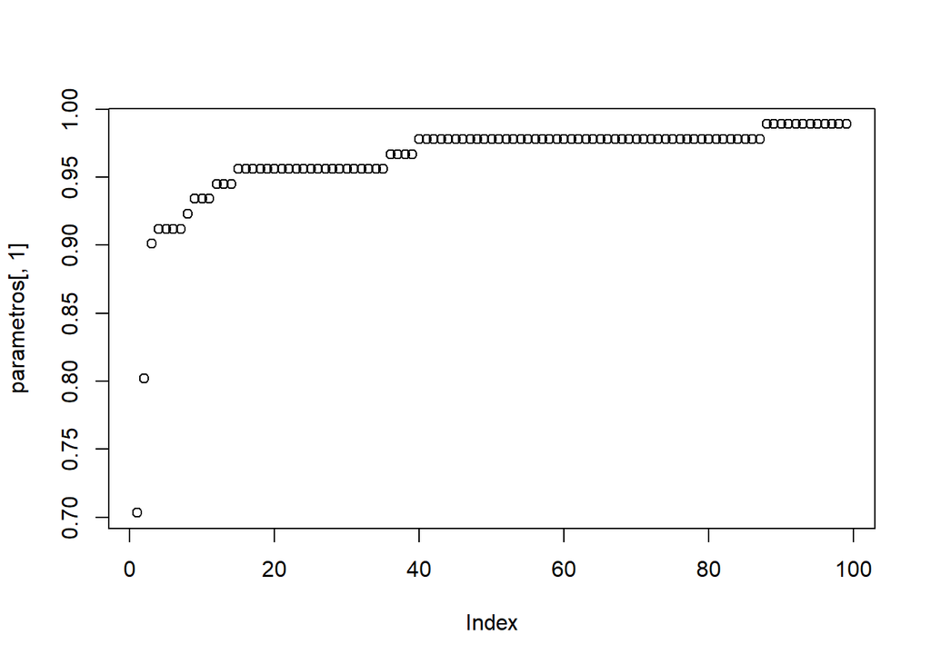

```r
# Hacemos una funcion que calcula los índices para el test y cierta predicción, variando
# el cutoff. De este modo, probando varios cutoffs buscaremos el que mejore los índices.
calcula_indices <- function(test,prediccion,cutoff=0.5){
  test$predicted <- ifelse(prediccion <= cutoff,0,1)
  tt <- table(test$Class,test$predicted)
  sensibilidad = tt[1,1]/(tt[1,1]+tt[1,2])
  especificidad = tt[2,2]/(tt[2,2]+tt[2,1])
  precision = (tt[1,1]+tt[2,2])/(tt[1,1]+tt[1,2]+tt[2,1]+tt[2,2])
  return(c(sensibilidad,especificidad,precision))
}

cutoffs <- seq(0.01,0.99,by=0.01)
parametros <- matrix(, nrow = length(cutoffs), ncol = 3)
k = 1
for(i in cutoffs){
  parametros[k,] <- calcula_indices(test,prediccion,i)
  k=k+1
}

plot(parametros[,1]) # vemos que las sensibilidades van aumentando
```

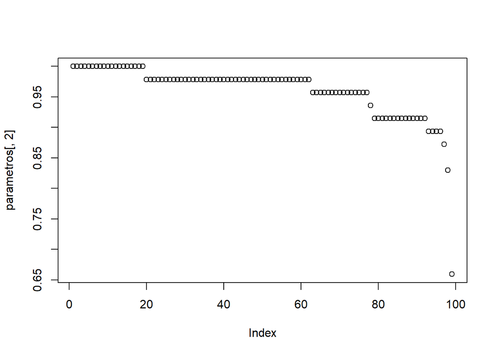

```r
plot(parametros[,2]) # pero las especificidades disminuyen
```

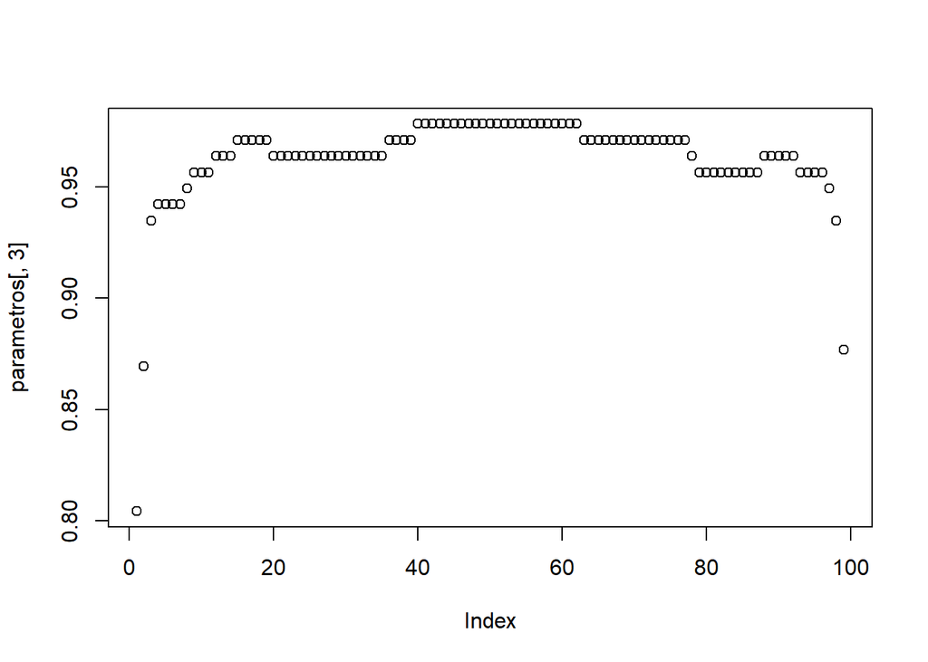

```r
plot(parametros[,3]) # las precisiones si que alcanzan un máximo en torno al centro
```

Podemos asumir que el cutoff óptimo está en el centro, o sea, en 0.5, que es el que pusimos.

En definitiva, nos quedamos con que el modelo final es el siguiente, como ya se estableció

```r
mod <- glm("Class ~ CT + MA + BN + BC + NN",
           data = train[,-1], family = binomial(link="logit"))
summary(mod)
```

```
##
## Call:
## glm(formula = "Class ~ CT + MA + BN + BC + NN", family = binomial(link = "logit"),
##     data = train[, -1])
##
## Coefficients:
##              Estimate Std. Error z value Pr(>|z|)
## (Intercept) -10.77456    1.38335  -7.789 6.77e-15 ***
## CT            0.81236    0.16822   4.829 1.37e-06 ***
## MA            0.44496    0.13225   3.364 0.000767 ***
## BN            0.41318    0.09601   4.304 1.68e-05 ***
## BC            0.58222    0.16080   3.621 0.000294 ***
## NN            0.41778    0.11714   3.567 0.000362 ***
## ---
## Signif. codes:  0 '***' 0.001 '**' 0.01 '*' 0.05 '.' 0.1 ' ' 1
##
## (Dispersion parameter for binomial family taken to be 1)
##
##     Null deviance: 697.515  on 537  degrees of freedom
## Residual deviance:  83.065  on 532  degrees of freedom
##   (21 observations deleted due to missingness)
## AIC: 95.065
##
## Number of Fisher Scoring iterations: 8
```

Se ha encontrado que este es el modelo que mejor se ajusta a los datos, el que mejor los representa y predice.